# Customer LifeTime Value Prediction

### Monthly Premium Auto

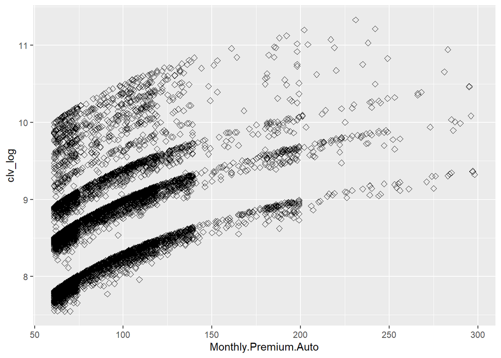

### Months Since Last Claim

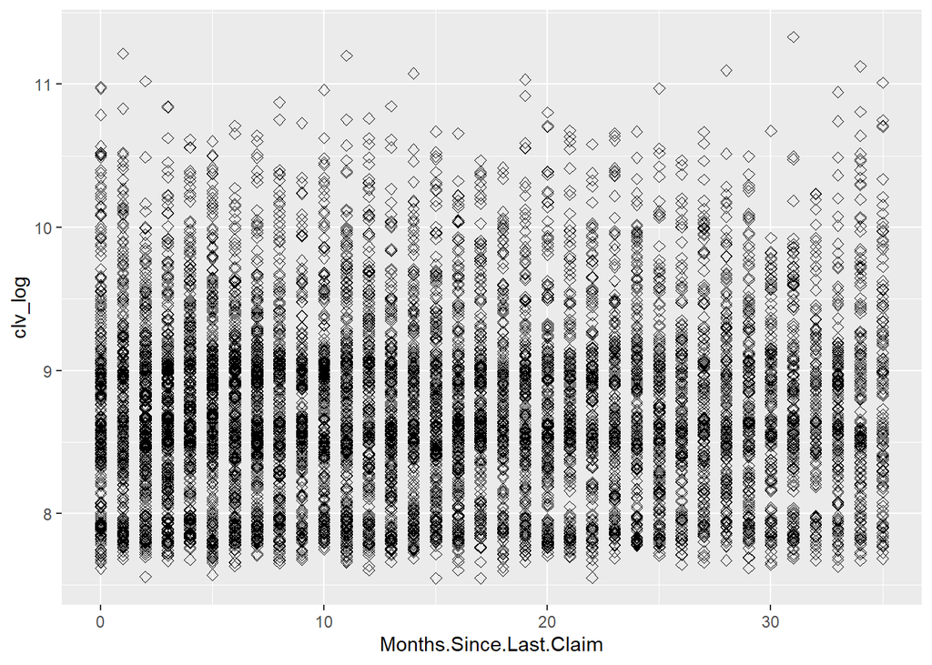

As shown below in the summary of the difference between Months Since Policy Inception and Months Since Last Claim , it seems like for some customers, the months since activation of policy plan is lesser than the months since the last claim. Could the months since last claim refer to an older claim in these cases?

```
##    Min. 1st Qu.  Median    Mean 3rd Qu.    Max.
##  -34.00    8.00   33.00   32.97   57.00   99.00
```

### Months Since Policy Inception

As seen above, few values of this column are lesser than the values of the Months Since Last Claim column.

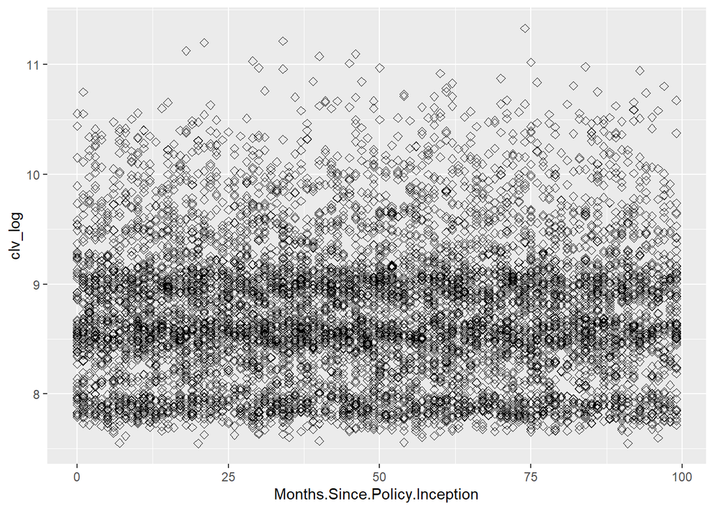

### Number of Open Complaints

This is a discrete ratio data type.

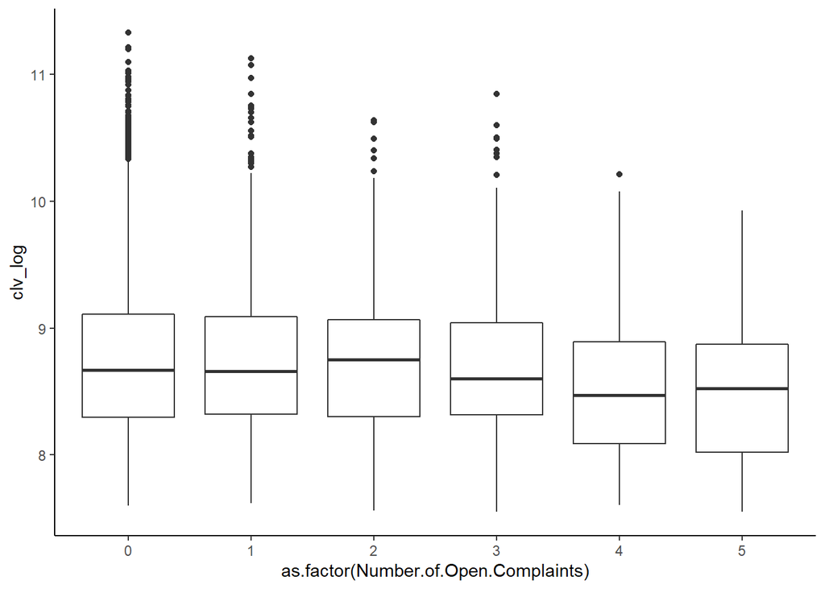

### Number of Policies

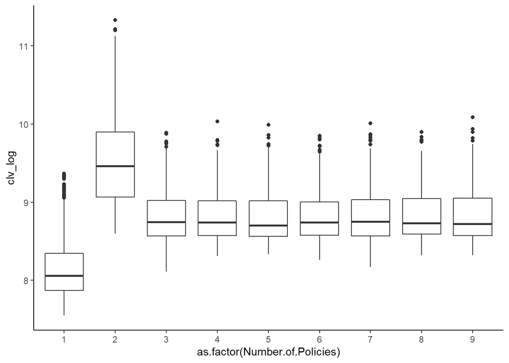

### Policy Type

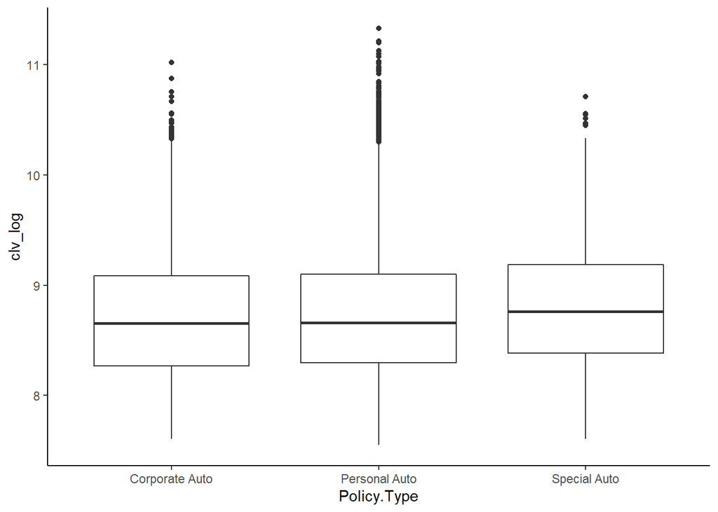

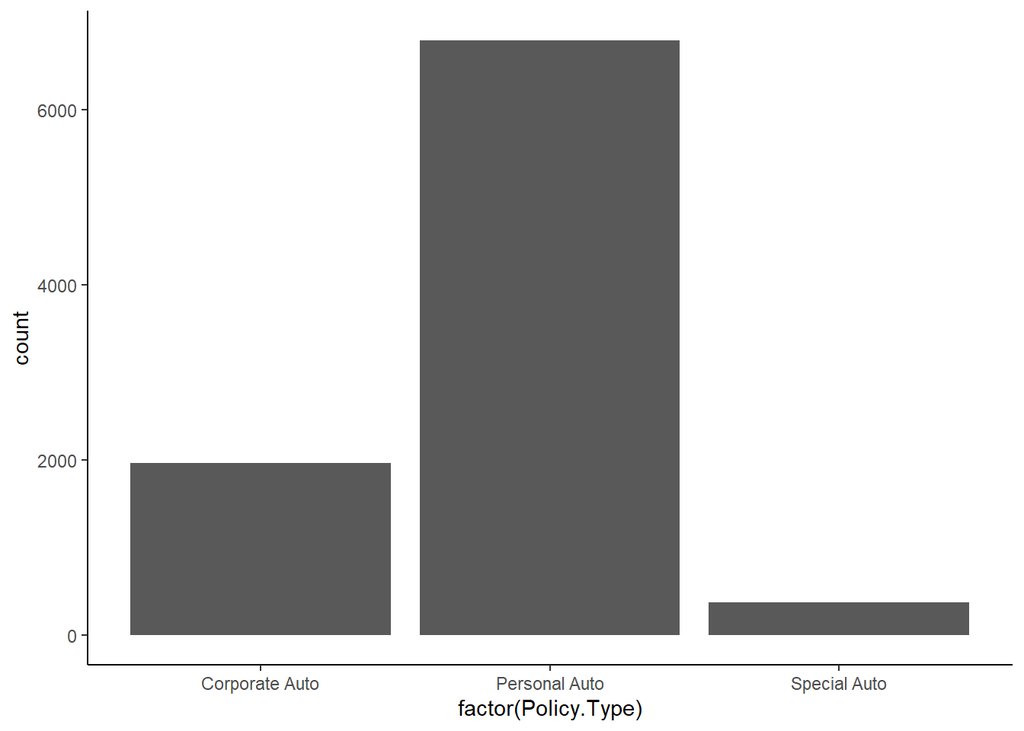

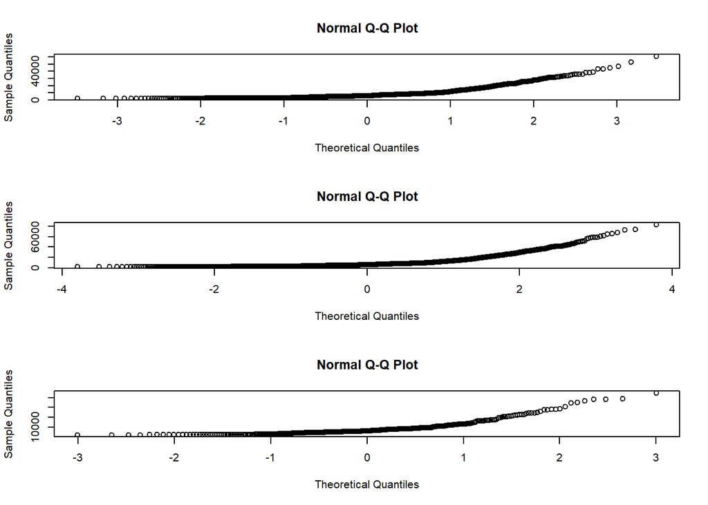

```
## # A tibble: 3 x 5
##   Policy.Type    count  mean    sd median
##   <chr>          <int> <dbl> <dbl>  <dbl>
## 1 Corporate Auto  1968 7814. 6342.  5736.
## 2 Personal Auto   6788 8027. 7011.  5770.
## 3 Special Auto     378 8594. 6962.  6369.
```

```
## Levene's Test for Homogeneity of Variance (center = median)
##         Df F value Pr(>F)
## group    2   1.498 0.2236
##       9131
```

```
##
##  Kruskal-Wallis rank sum test
##
## data:  Customer.Lifetime.Value by Policy.Type
## Kruskal-Wallis chi-squared = 4.6075, df = 2, p-value = 0.09988
```

Therefore, the levels are drawn from the same population.

### Policy

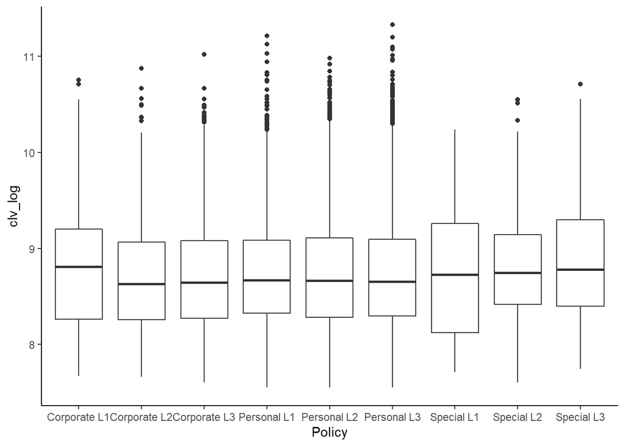

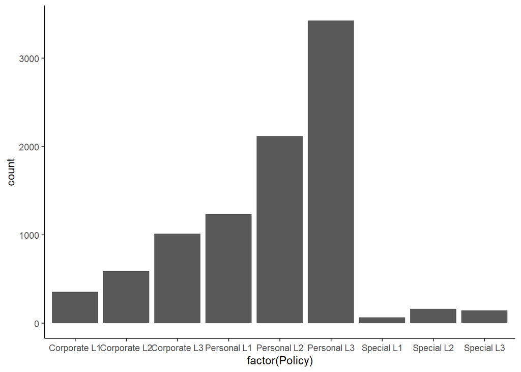

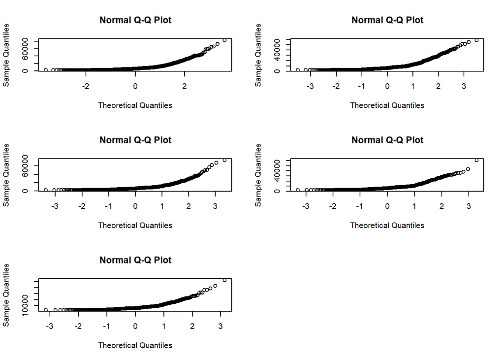

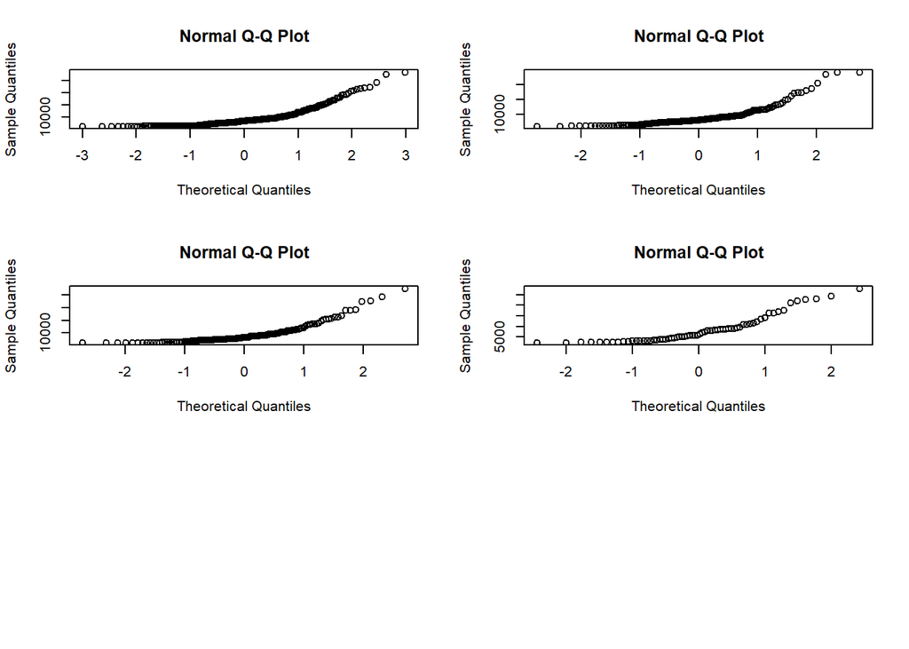

```
## # A tibble: 9 x 5
##   Policy       count  mean    sd median
##   <chr>        <int> <dbl> <dbl>  <dbl>
## 1 Corporate L1   359 8475. 7058.  6699.
## 2 Corporate L2   595 7598. 6040.  5596.
## 3 Corporate L3  1014 7708. 6237.  5665.
## 4 Personal L1   1240 7990. 7079.  5805.
## 5 Personal L2   2122 8055. 6836.  5801.
## 6 Personal L3   3426 8024. 7094.  5739.
## 7 Special L1      66 8333. 6242.  6175.
## 8 Special L2     164 8327. 6695.  6280.
## 9 Special L3     148 9007. 7556.  6517.
```

```
## Levene's Test for Homogeneity of Variance (center = median)
##         Df F value Pr(>F)
## group    8  1.1337 0.3366
##       9125
```

```
##
##  Kruskal-Wallis rank sum test
##
## data:  Customer.Lifetime.Value by Policy
## Kruskal-Wallis chi-squared = 7.9444, df = 8, p-value = 0.4389
```

Therefor the groups are from the same population.

### Renew Offer Type

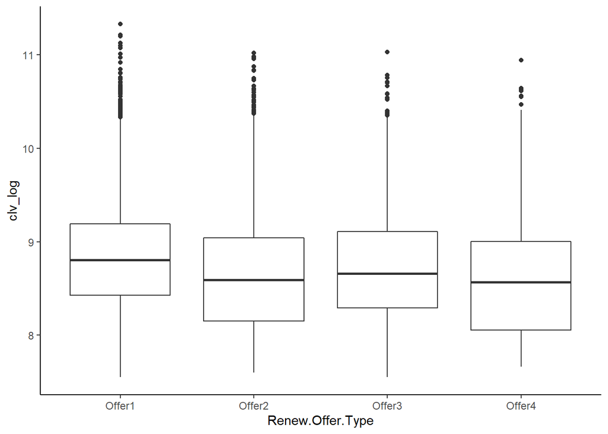

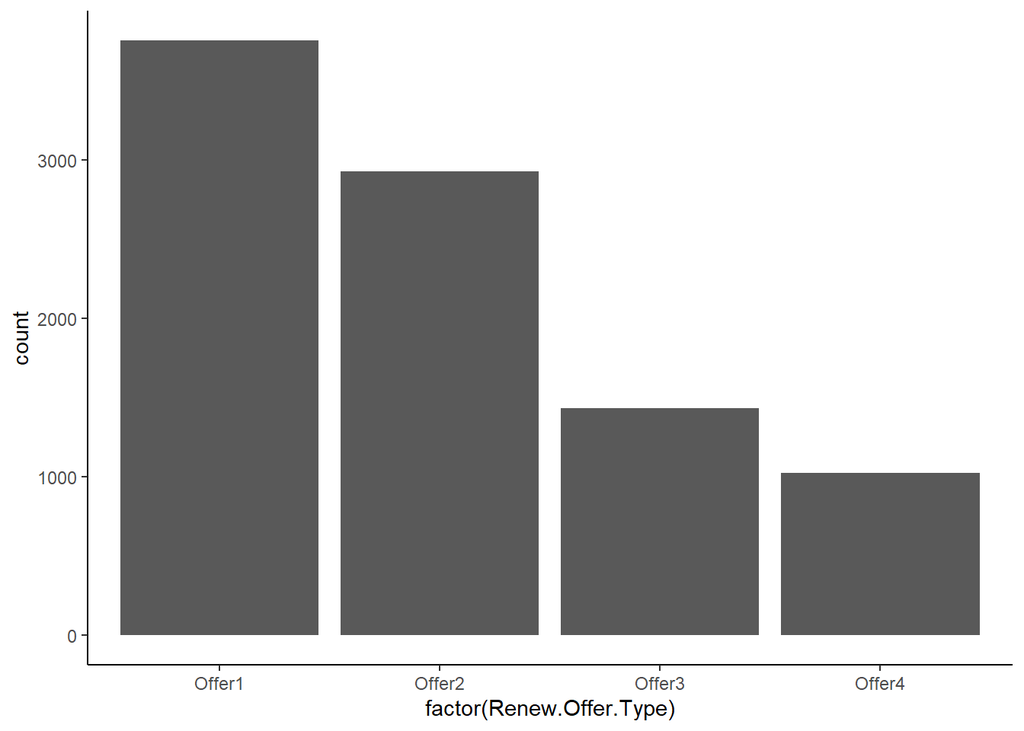

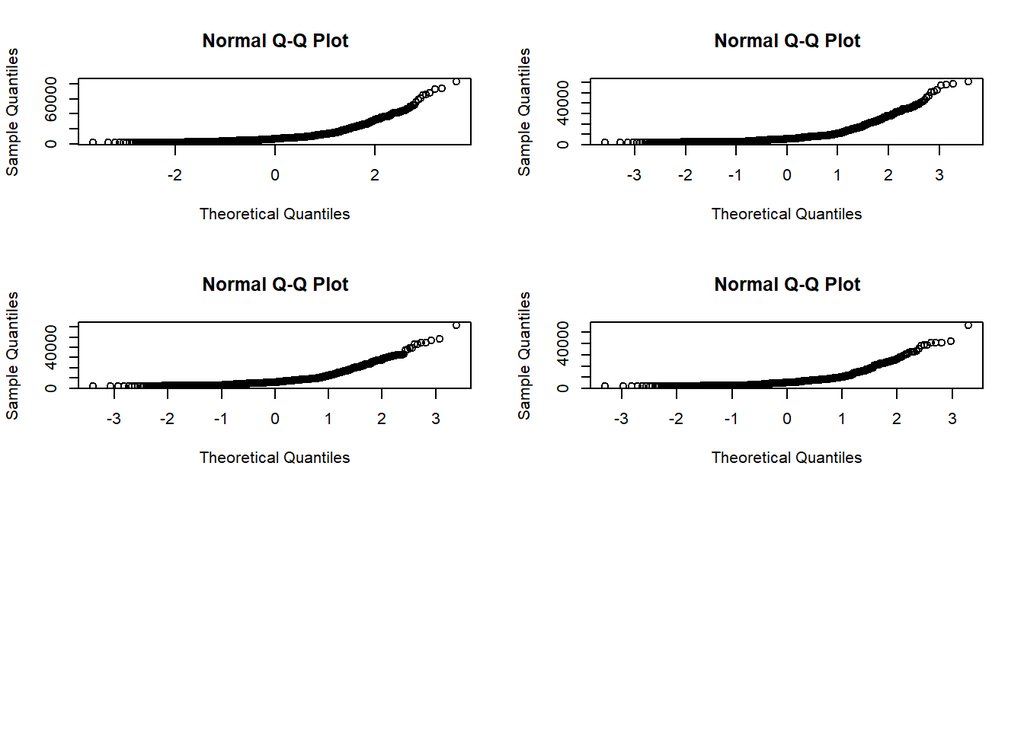

```
## # A tibble: 4 x 5
##   Renew.Offer.Type count  mean    sd median
##   <chr>            <int> <dbl> <dbl>  <dbl>
## 1 Offer1            3752 8707. 7337.  6672.
## 2 Offer2            2926 7397. 6446.  5397.
## 3 Offer3            1432 7998. 6670.  5759.
## 4 Offer4            1024 7180. 6286.  5257.
```

```
## Levene's Test for Homogeneity of Variance (center = median)
##         Df F value    Pr(>F)
## group    3   6.763 0.0001494 ***
##       9130
## ---
## Signif. codes:  0 '***' 0.001 '**' 0.01 '*' 0.05 '.' 0.1 ' ' 1
```

The levels don’t have the same variances

### Sales Channel

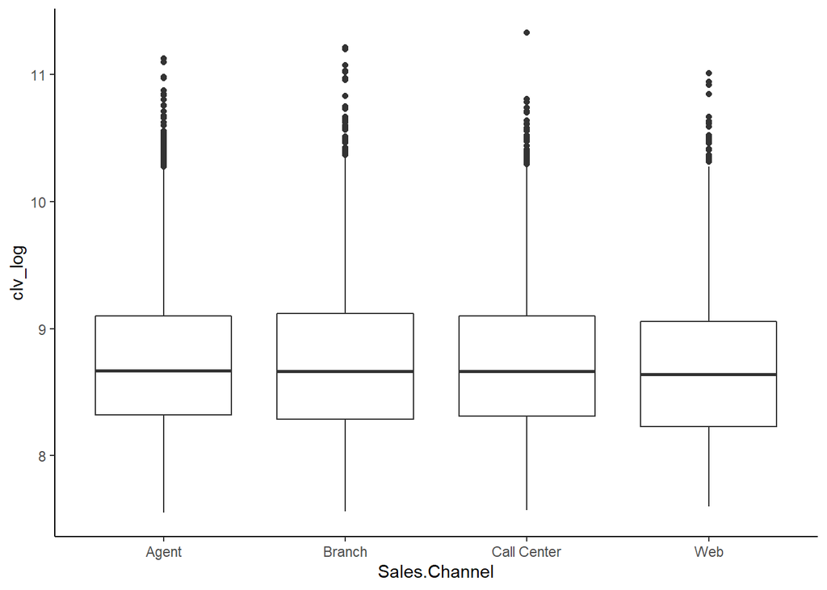

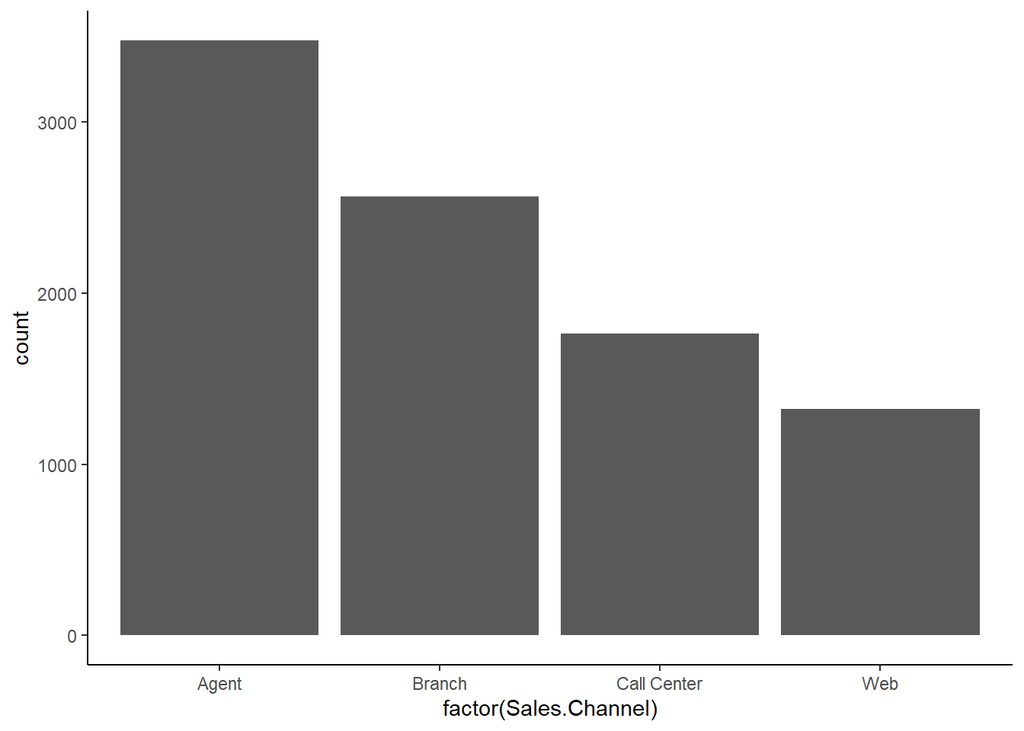

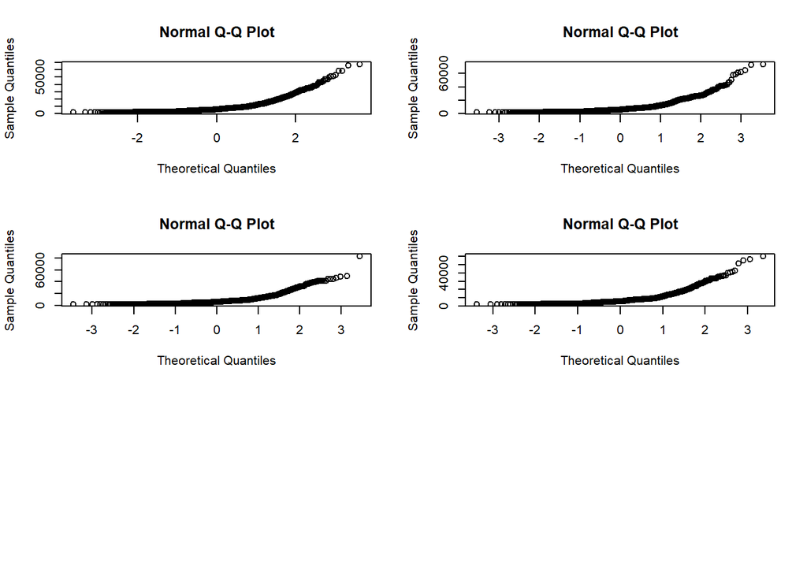

```
## # A tibble: 4 x 5
##   Sales.Channel count  mean    sd median
##   <chr>         <int> <dbl> <dbl>  <dbl>
## 1 Agent          3477 7958. 6630.  5831.
## 2 Branch         2567 8120. 7078.  5803.
## 3 Call Center    1765 8100. 7106.  5780.
## 4 Web            1325 7780. 6766.  5641.
```

```
## Levene's Test for Homogeneity of Variance (center = median)
##         Df F value Pr(>F)
## group    3  0.9477 0.4165
##       9130
```

```
##
##  Kruskal-Wallis rank sum test
##
## data:  Customer.Lifetime.Value by Sales.Channel
## Kruskal-Wallis chi-squared = 4.4918, df = 3, p-value = 0.213
```

### Total Claim Amount

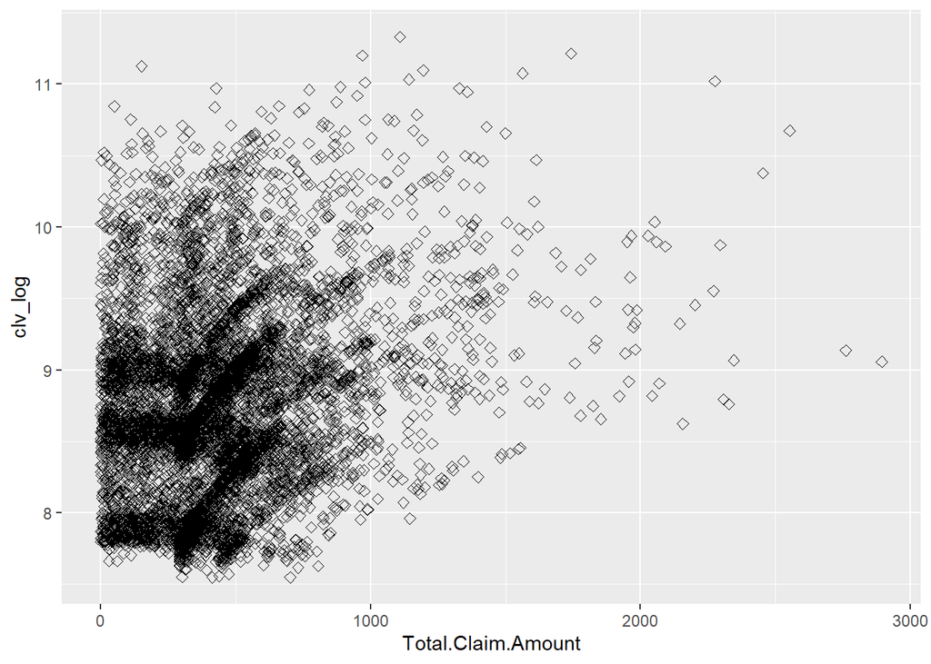

### Vehicle Class

As seen multiple times above, customers that insure Luxury SUV and Luxury Car have higher CLV on the whole. In fact these classes exclusively exist only in the rows with above median CLV.

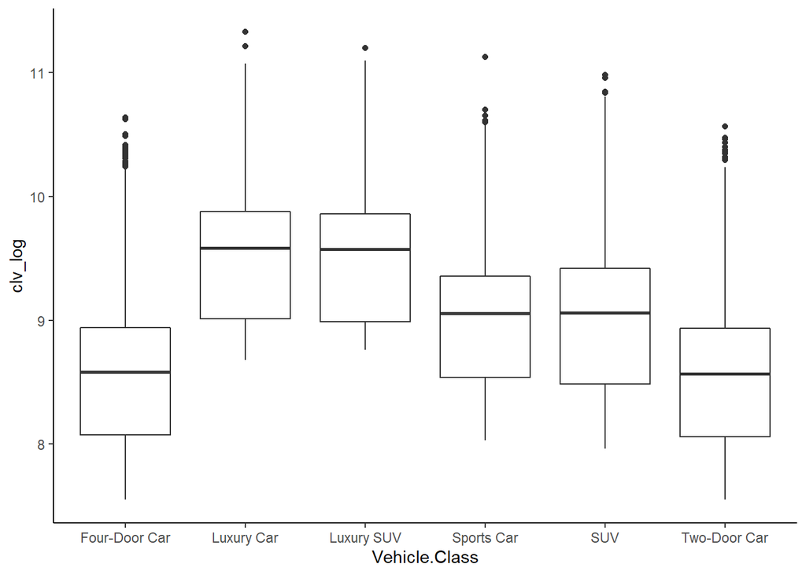

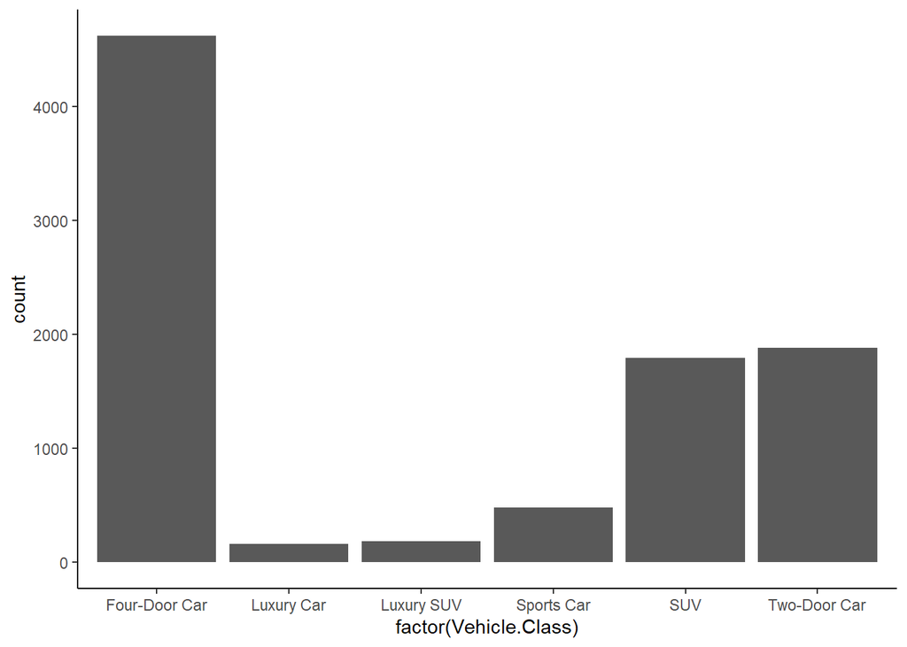

The reason could be that the total claim amount for these cars are higher than the other car.

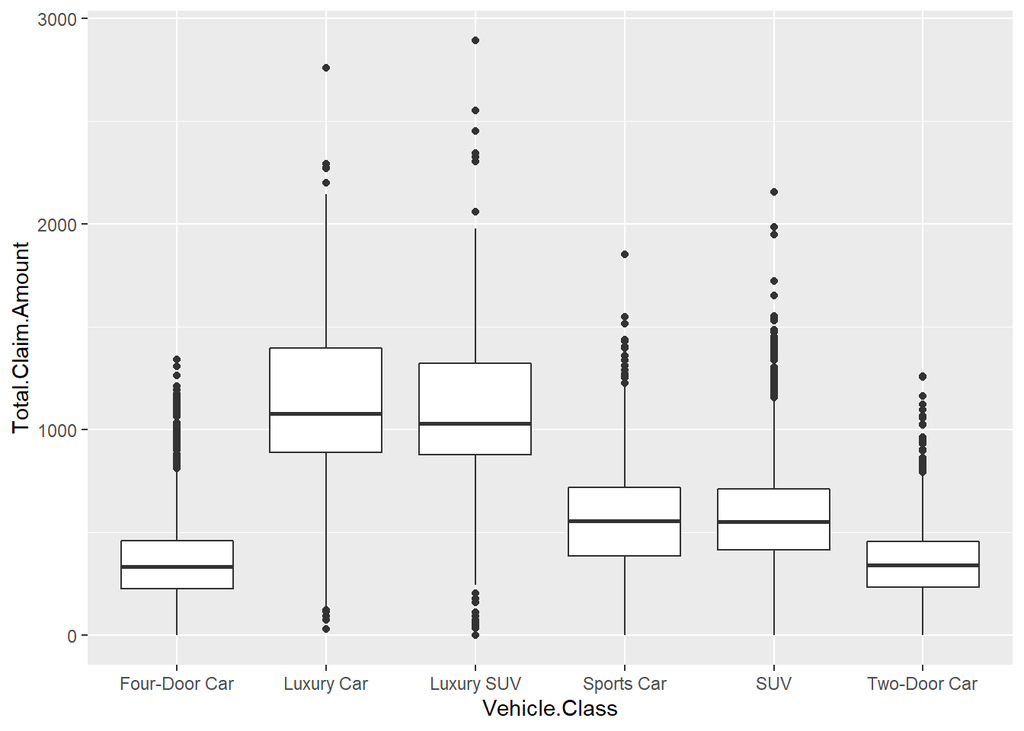

Clearly, the monthly premium is greater for Luxury SUV and Luxury car even though the income of the customers that have insured for these cars are equally distributed.

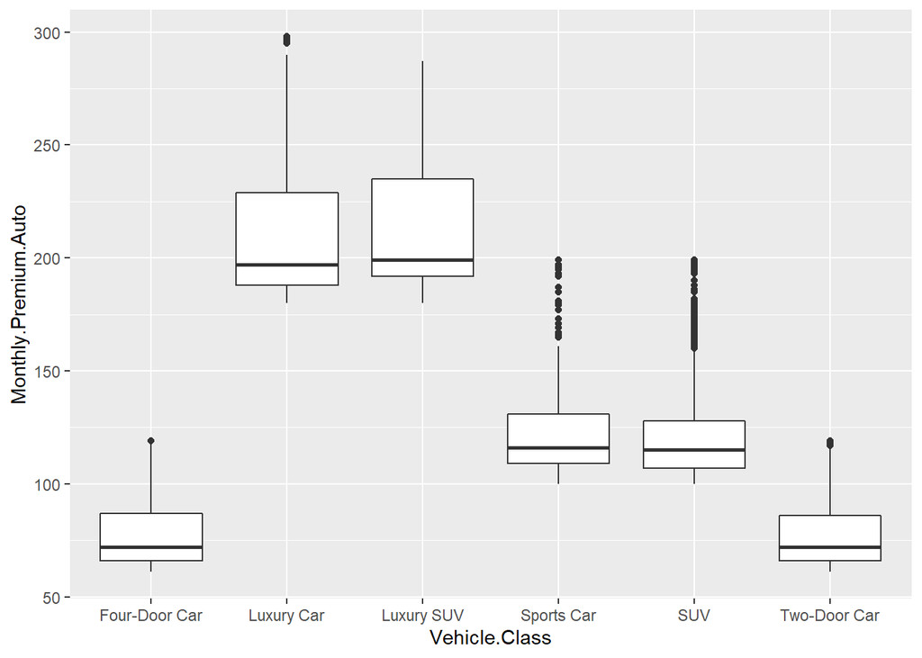

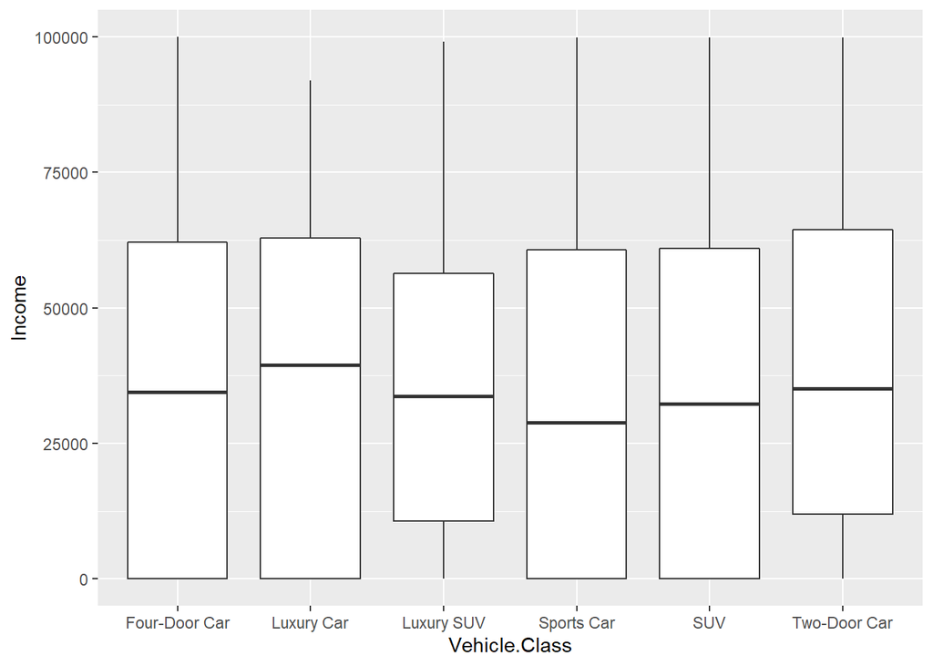

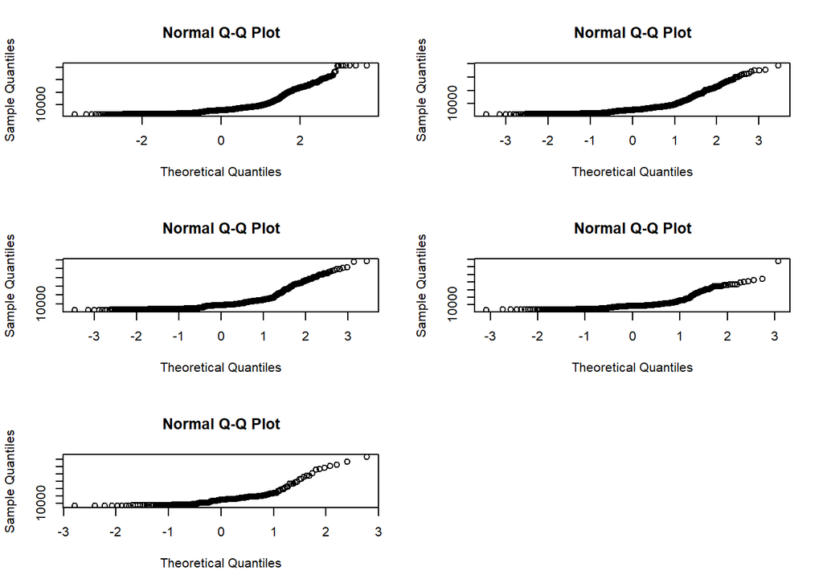

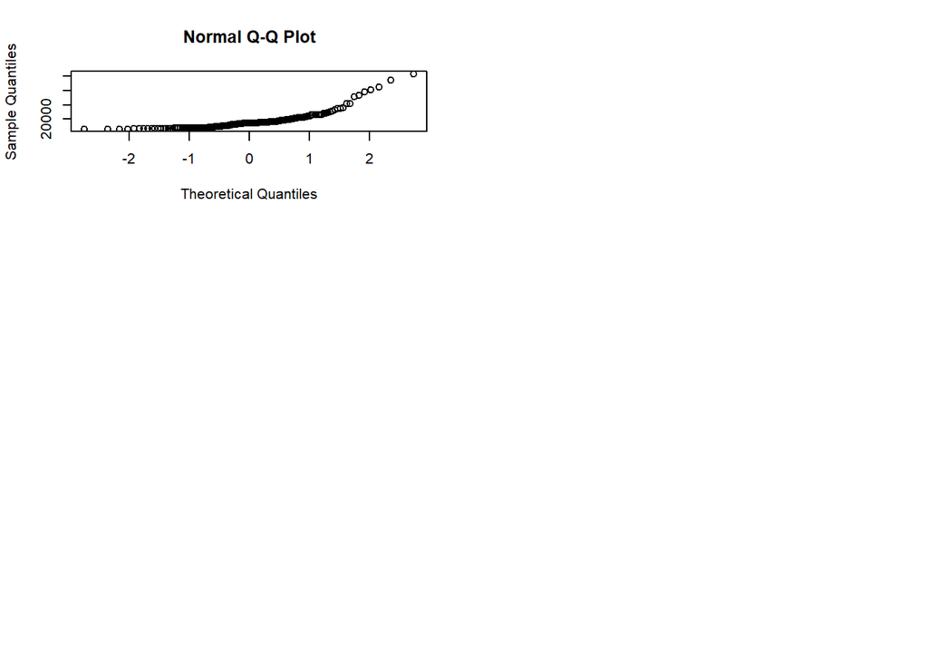

```
## # A tibble: 6 x 5
##   Vehicle.Class count   mean     sd median
##   <chr>         <int>  <dbl>  <dbl>  <dbl>
## 1 Four-Door Car  4621  6632.  5165.  5320.
## 2 Luxury Car      163 17053. 12542. 14510.
## 3 Luxury SUV      184 17123. 12672. 14396.
## 4 Sports Car      484 10751.  8462.  8555.
## 5 SUV            1796 10444.  7940.  8593.
## 6 Two-Door Car   1886  6671.  5164.  5267.
```

```
## Levene's Test for Homogeneity of Variance (center = median)
##         Df F value    Pr(>F)
## group    5  79.503 < 2.2e-16 ***
##       9128
## ---
## Signif. codes:  0 '***' 0.001 '**' 0.01 '*' 0.05 '.' 0.1 ' ' 1
```

### Vehicle Size

This is yet another column that can be treated as a nominal variable.

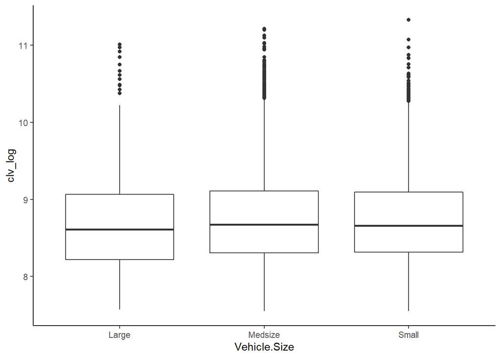

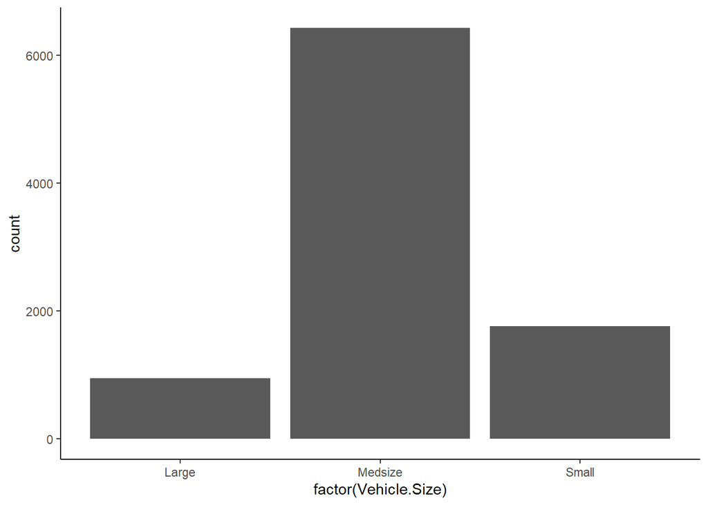

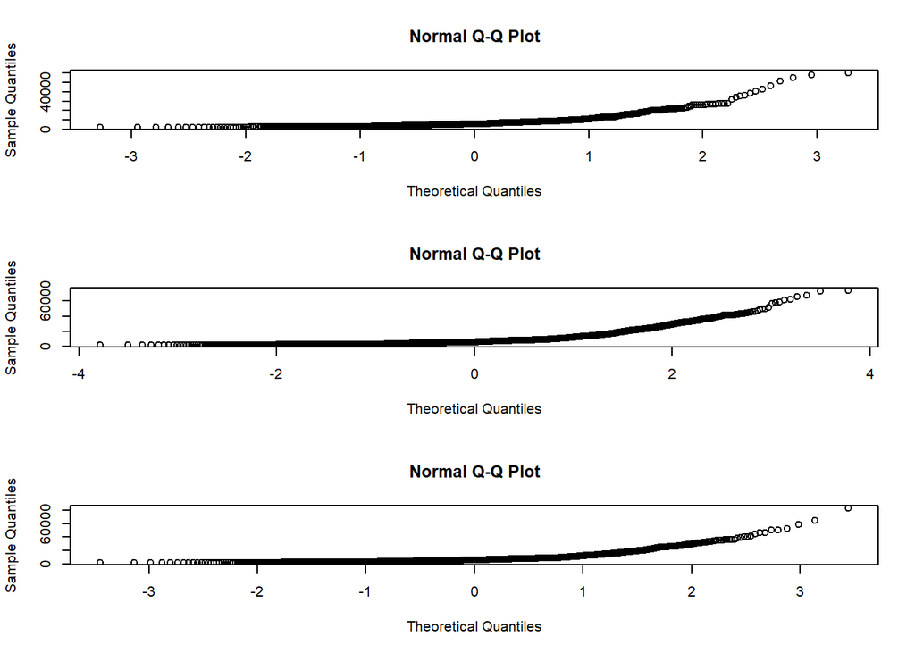

```
## # A tibble: 3 x 5
##   Vehicle.Size count  mean    sd median
##   <chr>        <int> <dbl> <dbl>  <dbl>
## 1 Large          946 7545. 6625.  5483.
## 2 Medsize       6424 8051. 6833.  5845.
## 3 Small         1764 8085. 7128.  5757.
```

```
## Levene's Test for Homogeneity of Variance (center = median)
##         Df F value Pr(>F)
## group    2  0.8768 0.4161
##       9131
```

```
##
##  Kruskal-Wallis rank sum test
##
## data:  Customer.Lifetime.Value by Vehicle.Size
## Kruskal-Wallis chi-squared = 9.565, df = 2, p-value = 0.008375
```

# MODELING

### We tried out different models with different feature selection and different feature engineering

Data Dimension

Test Data

```
## [1] 1826   39
```

Train Data

```
## [1] 7308   39
```

## Model 1

### Basic Model

|  | RMSE | R2 | Adj.R2 | Fstatistic |
| --- | --- | --- | --- | --- |
| dendf | 5824.093 | 0.1724846 | 0.1675861 | 7264 |

| r.squared | adj.r.squared | sigma | statistic | p.value | df | logLik | AIC | BIC | deviance | df.residual | nobs |
| --- | --- | --- | --- | --- | --- | --- | --- | --- | --- | --- | --- |
| 0.1724846 | 0.1675861 | 6389.891 | 35.21127 | 0 | 43 | -74383.69 | 148857.4 | 149167.7 | 296594269111 | 7264 | 7308 |

## Model 2

### Converting the categorical features to factors

When you make a categorical variable a factor, R creates dummy variables that represent each of the possible states, for example when gender is made a factor it encodes as “male” and “female” and individually estimates a coefficient for the effect of each.Making a variable into a factor treats it as nominal feature which means it does not consider the options as being ordered in any way.so the working is similar to that of one hot encoding.

|  | RMSE | R2 | Adj.R2 | Fstatistic |
| --- | --- | --- | --- | --- |
| dendf | 5977.048 | 0.1952277 | 0.1734894 | 1777 |

| r.squared | adj.r.squared | sigma | statistic | p.value | df | logLik | AIC | BIC | deviance | df.residual | nobs |
| --- | --- | --- | --- | --- | --- | --- | --- | --- | --- | --- | --- |
| 0.1952277 | 0.1734894 | 6058.895 | 8.980792 | 0 | 48 | -18469.3 | 37038.59 | 37314.09 | 65234038769 | 1777 | 1826 |

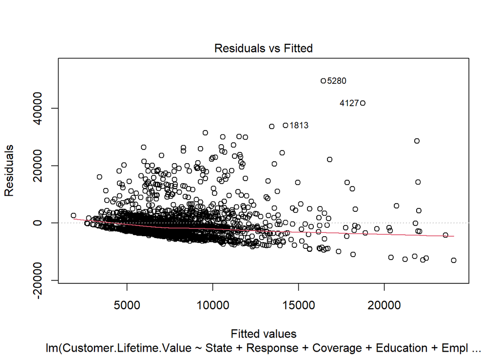

Residuals vs Fitted - Used to check the linear relationship assumptions. A horizontal line,at y=0, without distinct patterns is an indication for a linear relationship, what is good.The presence of a pattern may indicate a problem with some aspect of the linear model.

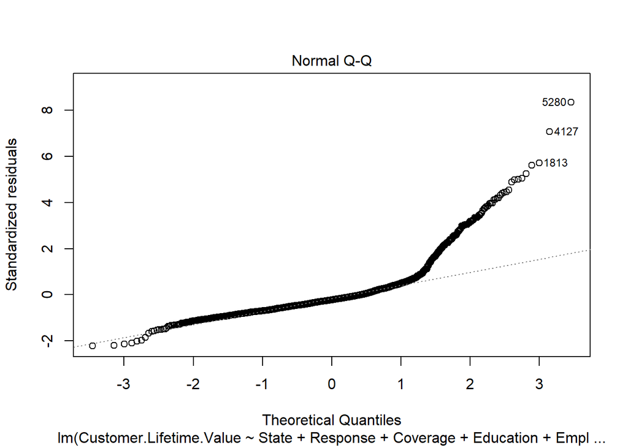

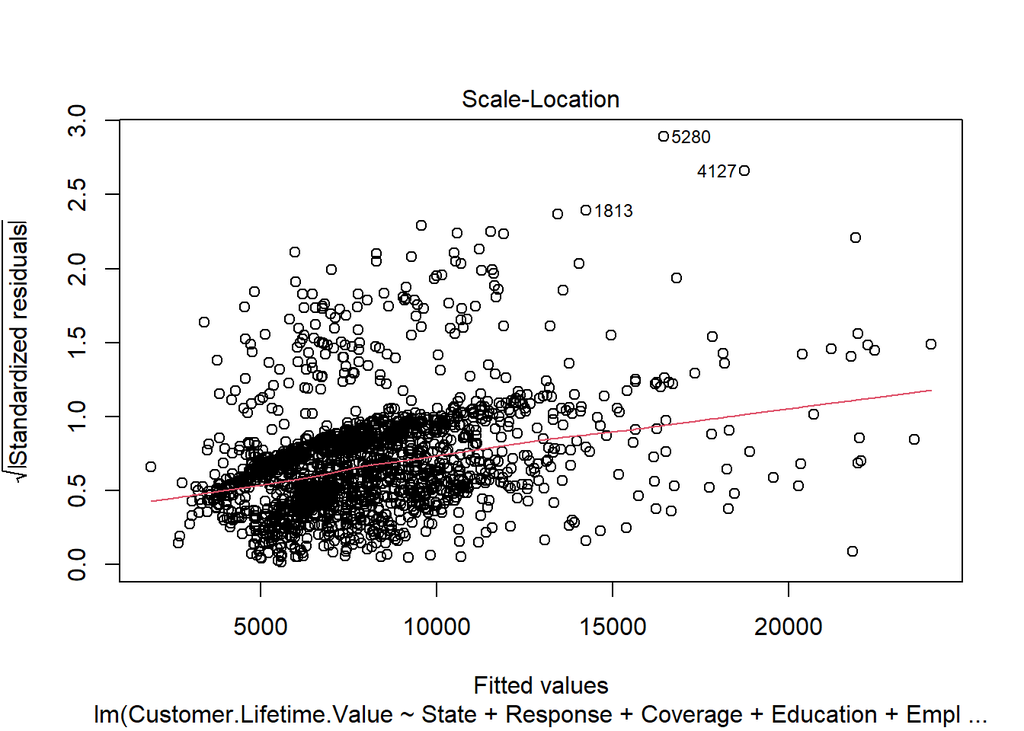

Scale-Location- Used to check the homogeneity of variance of the residuals (homoscedasticity). Horizontal line with equally spread points is a good indication of homoscedasticity. This is not the case in our example, as it can be seen that the variability (variances) of the residual points increases slightly with the value of the fitted outcome variable, suggesting non-constant variances in the residuals errors (or heteroscedasticity).

The violation of Normality,Heteroscedasticity and linear - independence can be fixed to some extent by transforming the dependent or independent variables.

## Model 3

### Tring out Different Tranformations on Dependent Variable

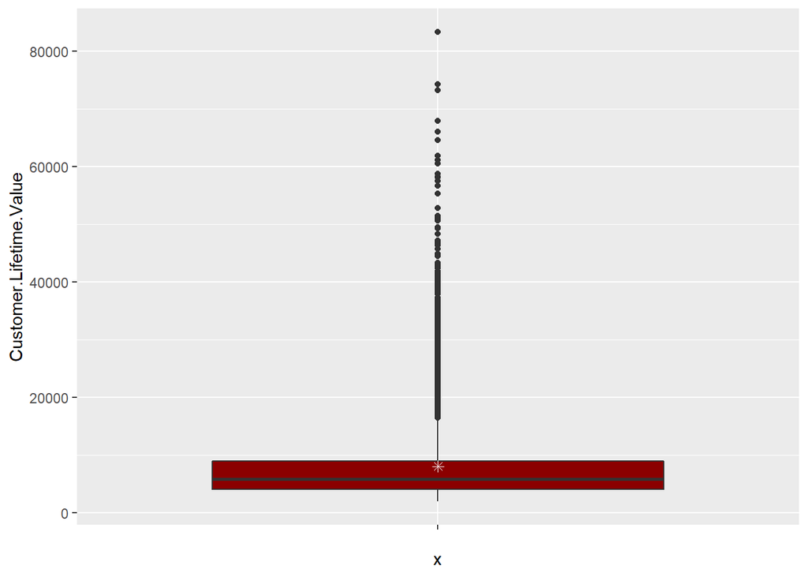

Outliers:

An outlier is a point that has an extreme outcome variable value. The presence of outliers may affect the interpretation of the model, because it increases the RSE.

Outliers can be identified by examining the standardized residual (or studentized residual), which is the residual divided by its estimated standard error. Standardized residuals can be interpreted as the number of standard errors away from the regression line.

#### Inverse of the dependent variable

Here we are trying out a standard transformation.

|  | RMSE | R2 | Adj.R2 | Fstatistic |
| --- | --- | --- | --- | --- |
| dendf | 10505.34 | 0.3162776 | 0.3144011 | 7287 |

| r.squared | adj.r.squared | sigma | statistic | p.value | df | logLik | AIC | BIC | deviance | df.residual | nobs |
| --- | --- | --- | --- | --- | --- | --- | --- | --- | --- | --- | --- |
| 0.3162776 | 0.3144011 | 9.15e-05 | 168.5417 | 0 | 20 | 57600.14 | -115156.3 | -115004.6 | 6.1e-05 | 7287 | 7308 |

The r square and adjusted r squared has improved for this model.

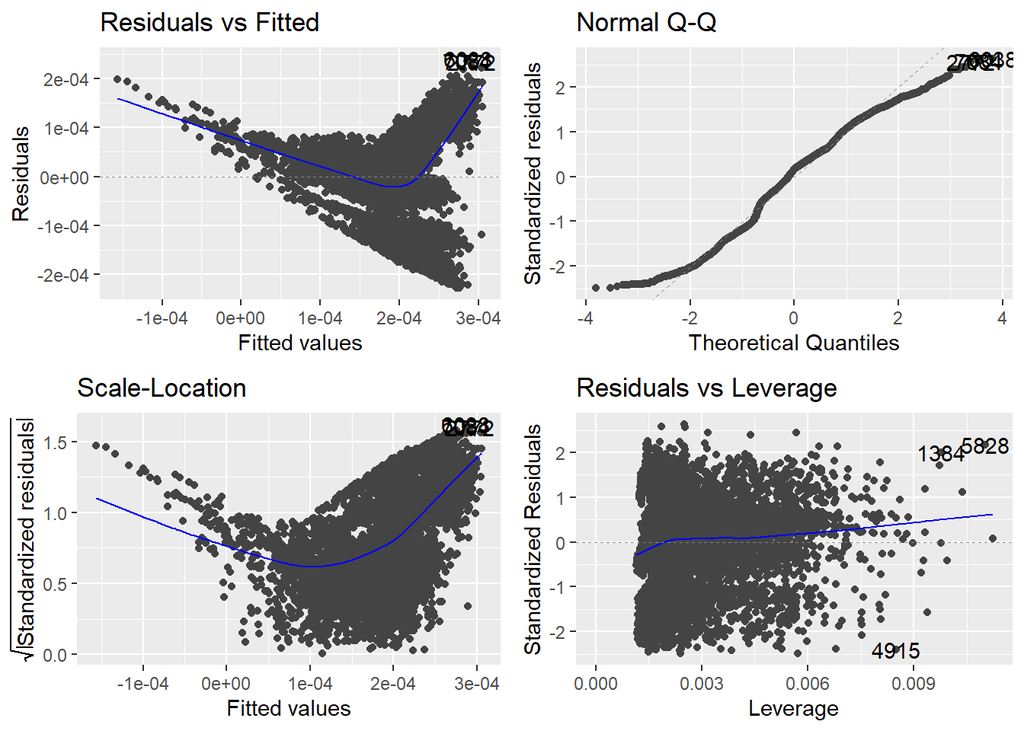

#### Square root

|  | RMSE | R2 | Adj.R2 | Fstatistic |
| --- | --- | --- | --- | --- |
| dendf | 10437.84 | 0.2038087 | 0.2016235 | 7287 |

| r.squared | adj.r.squared | sigma | statistic | p.value | df | logLik | AIC | BIC | deviance | df.residual | nobs |
| --- | --- | --- | --- | --- | --- | --- | --- | --- | --- | --- | --- |
| 0.2038087 | 0.2016235 | 27.56525 | 93.26615 | 0 | 20 | -34596.48 | 69236.95 | 69388.68 | 5536974 | 7287 | 7308 |

The r square and adjusted r squared scores has gown down.

#### log Transformation

|  | RMSE | R2 | Adj.R2 | Fstatistic |
| --- | --- | --- | --- | --- |
| dendf | 6263.539 | 0.1678673 | 0.1623648 | 7259 |

| r.squared | adj.r.squared | sigma | statistic | p.value | df | logLik | AIC | BIC | deviance | df.residual | nobs |
| --- | --- | --- | --- | --- | --- | --- | --- | --- | --- | --- | --- |
| 0.1678673 | 0.1623648 | 6286.875 | 30.50766 | 0 | 48 | -74262.39 | 148624.8 | 148969.6 | 286910505881 | 7259 | 7308 |

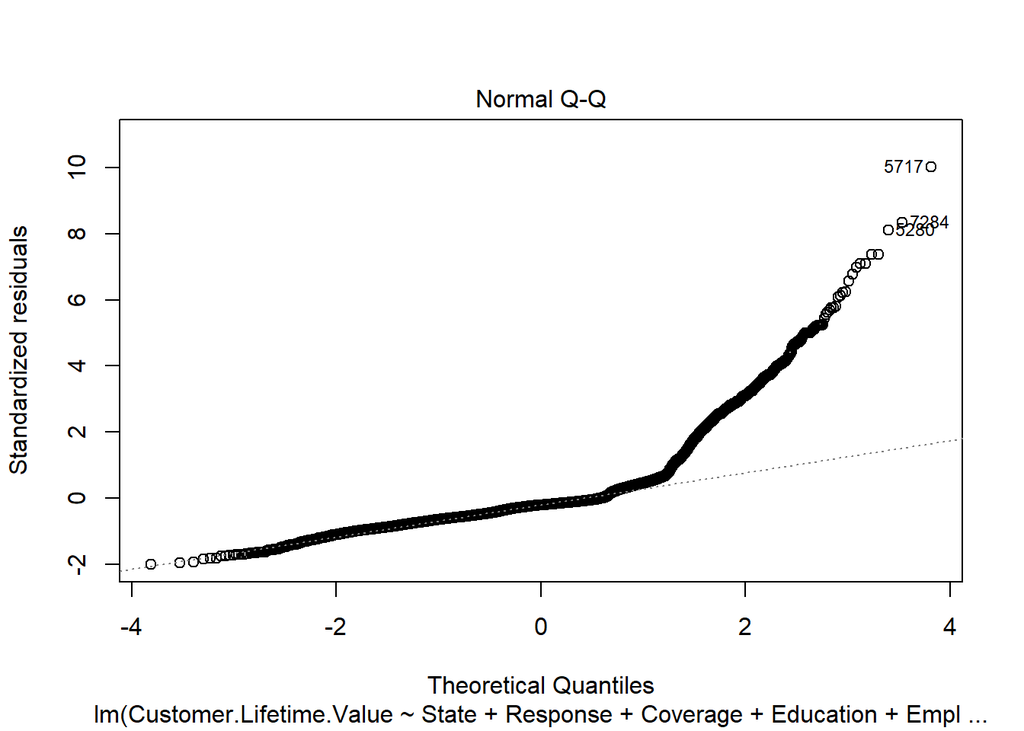

## Model 6

Trying out outlier treatment of numerical(continous with lots of unique values) columns with high percentage of outliers namely the monthlypremiumauto and totalclaimamount.

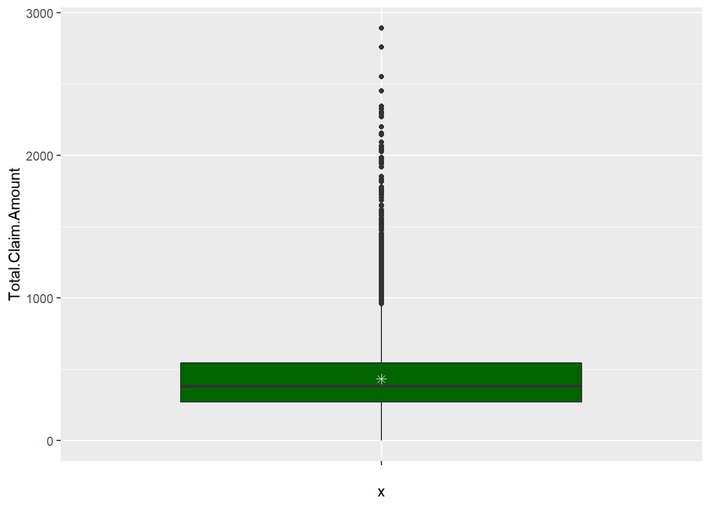

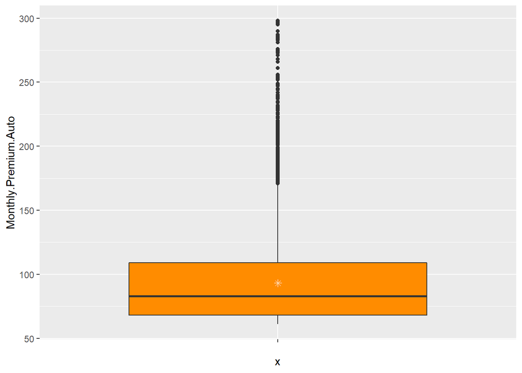

|  | RMSE | R2 | Adj.R2 | Fstatistic |
| --- | --- | --- | --- | --- |
| dendf | 0.5598291 | 0.2693107 | 0.2644791 | 7259 |

| r.squared | adj.r.squared | sigma | statistic | p.value | df | logLik | AIC | BIC | deviance | df.residual | nobs |
| --- | --- | --- | --- | --- | --- | --- | --- | --- | --- | --- | --- |
| 0.2693107 | 0.2644791 | 0.5600177 | 55.73865 | 0 | 48 | -6107.938 | 12315.88 | 12660.71 | 2276.566 | 7259 | 7308 |

# Model 7

Here we are trying out a creative feature engineering from the domain knowledge that CLTV is proportional to the RMF of the customer. Therefore, New feature = Monthly.Premium.Auto*(No.of.Months.Since.LastClaim + No.of.Months.Policy.Inception)- Total.Claim.Amount. The feature represents the total monetary value of the customer to the company.This is not entirely correct as we don’t have enough information regarding premiums of other policies and the adding of months is the only way we have to find the total time period a customer is assosiate with the company.

|  | RMSE | R2 | Adj.R2 | Fstatistic |
| --- | --- | --- | --- | --- |
| dendf | 0.5597312 | 0.2694373 | 0.2645051 | 7258 |

| r.squared | adj.r.squared | sigma | statistic | p.value | df | logLik | AIC | BIC | deviance | df.residual | nobs |
| --- | --- | --- | --- | --- | --- | --- | --- | --- | --- | --- | --- |
| 0.2694373 | 0.2645051 | 0.5600078 | 54.62872 | 0 | 49 | -6107.305 | 12316.61 | 12668.34 | 2276.172 | 7258 | 7308 |

|  | RMSE | R2 | Adj.R2 | Fstatistic |
| --- | --- | --- | --- | --- |
| dendf | 6.606517 | 0.2705766 | 0.2684742 | 7286 |

| r.squared | adj.r.squared | sigma | statistic | p.value | df | logLik | AIC | BIC | deviance | df.residual | nobs |
| --- | --- | --- | --- | --- | --- | --- | --- | --- | --- | --- | --- |
| 0.2705766 | 0.2684742 | 0.062819 | 128.7006 | 0 | 21 | 9866.283 | -19686.57 | -19527.94 | 28.75224 | 7286 | 7308 |

## Model 7

### Stepwise Regression

For feature selection

```
##
## Call:
## lm(formula = Customer.Lifetime.Value ~ Education + EmploymentStatus +
##     Marital.Status + Monthly.Premium.Auto + Policy + Number.of.Open.Complaints +
##     Number.of.Policies + Renew.Offer.Type, data = data)
##
## Coefficients:
##                   (Intercept)               EducationCollege
##                      4.402290                       0.013868
##               EducationDoctor  EducationHigh School or Below
##                     -0.032508                       0.038824
##               EducationMaster       EmploymentStatusEmployed
##                      0.034656                       0.073489
## EmploymentStatusMedical Leave        EmploymentStatusRetired
##                     -0.033590                      -0.019570
##    EmploymentStatusUnemployed          Marital.StatusMarried
##                     -0.030282                       0.002475
##          Marital.StatusSingle           Monthly.Premium.Auto
##                     -0.041094                       0.962858
##            PolicyCorporate L2             PolicyCorporate L3
##                     -0.143765                      -0.115038
##             PolicyPersonal L1              PolicyPersonal L2
##                     -0.102419                      -0.068714
##             PolicyPersonal L3               PolicySpecial L1
##                     -0.094193                       0.068014
##              PolicySpecial L2               PolicySpecial L3
##                     -0.021664                       0.022634
##     Number.of.Open.Complaints             Number.of.Policies
##                     -0.029162                       0.052492
##        Renew.Offer.TypeOffer2         Renew.Offer.TypeOffer3
##                     -0.130170                      -0.074614
##        Renew.Offer.TypeOffer4
##                     -0.136810
```

|  | RMSE | R2 | Adj.R2 | Fstatistic |
| --- | --- | --- | --- | --- |
| dendf | 0.5575196 | 0.2642439 | 0.2628315 | 7293 |

| r.squared | adj.r.squared | sigma | statistic | p.value | df | logLik | AIC | BIC | deviance | df.residual | nobs |
| --- | --- | --- | --- | --- | --- | --- | --- | --- | --- | --- | --- |
| 0.2642439 | 0.2628315 | 0.5606446 | 187.0894 | 0 | 14 | -6133.189 | 12298.38 | 12408.73 | 2292.353 | 7293 | 7308 |

## Model 8

#### Transforming numerical variables to factors

Here we tranform the numerical independent variables no.of.open.complaints and no.of.policies to factor datatype so that their sub categories get one hot encoded and all of them get a regression coefficient assigned to it.

|  | RMSE | R2 | Adj.R2 | Fstatistic |
| --- | --- | --- | --- | --- |
| dendf | 0.2133726 | 0.9030995 | 0.9027668 | 7282 |

| r.squared | adj.r.squared | sigma | statistic | p.value | df | logLik | AIC | BIC | deviance | df.residual | nobs |
| --- | --- | --- | --- | --- | --- | --- | --- | --- | --- | --- | --- |
| 0.9030995 | 0.9027668 | 0.2027743 | 2714.69 | 0 | 25 | 1304.518 | -2555.035 | -2368.824 | 299.4169 | 7282 | 7308 |

### MAPE

The use of the MAPE as a loss function for regression analysis is feasible both on a practical point of view and on a theoretical one, since the existence of an optimal model and the consistency of the empirical risk minimization can be proved. Problems can occur when calculating the MAPE value with a series of small denominators.

```
## [1] 0.0118322
```

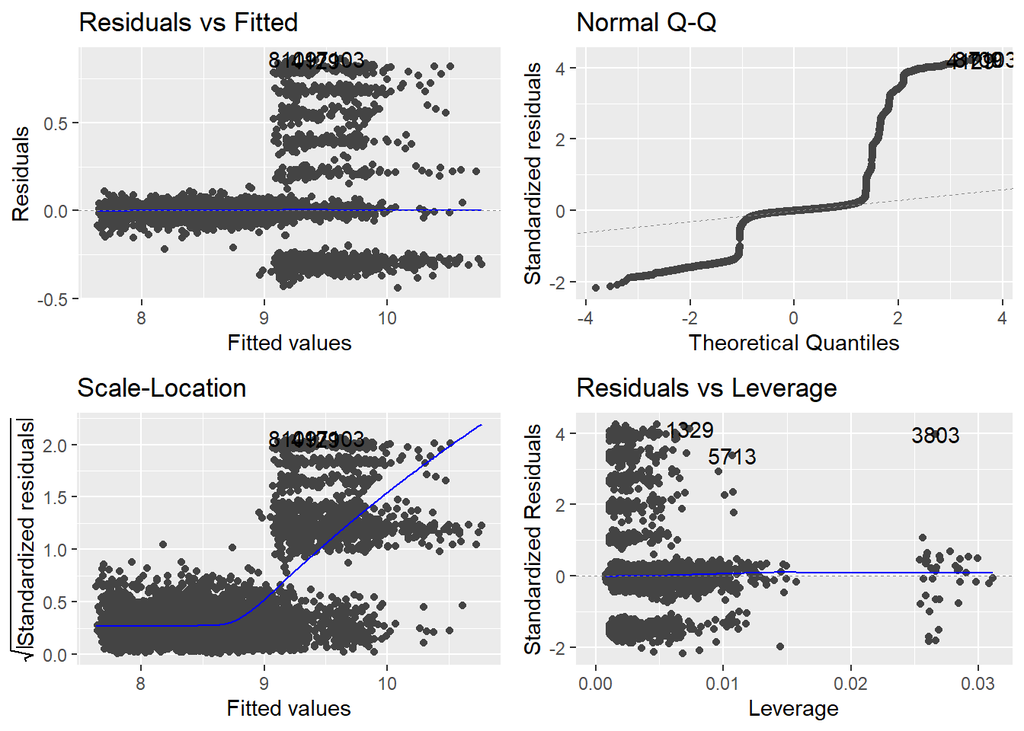

Residuals vs Fitted. Used to check the linear relationship assumptions. A horizontal line, without distinct patterns is an indication for a linear relationship, what is good. Normal Q-Q. Used to examine whether the residuals are normally distributed. It’s good if residuals points follow the straight dashed line Scale-Location (or Spread-Location). Used to check the homogeneity of variance of the residuals (homoscedasticity). Horizontal line with equally spread points is a good indication of homoscedasticity. This is not the case in our example, where we have a heteroscedasticity problem Residuals vs Leverage. Used to identify influential cases, that is extreme values that might influence the regression results when included or excluded from the analysis. This plot will be described further in the next sections.

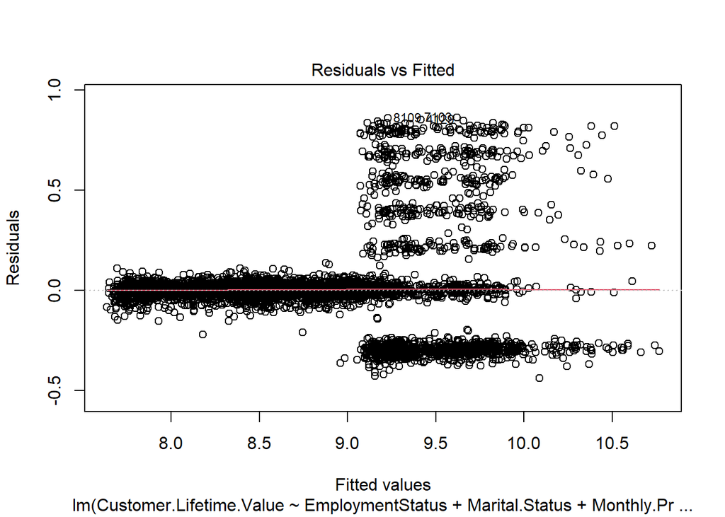

Ideally, the residual plot will show no fitted pattern. That is, the red line should be approximately horizontal at zero. The presence of a pattern may indicate a problem with some aspect of the linear model.

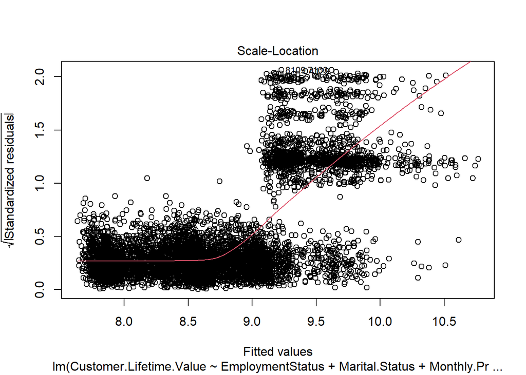

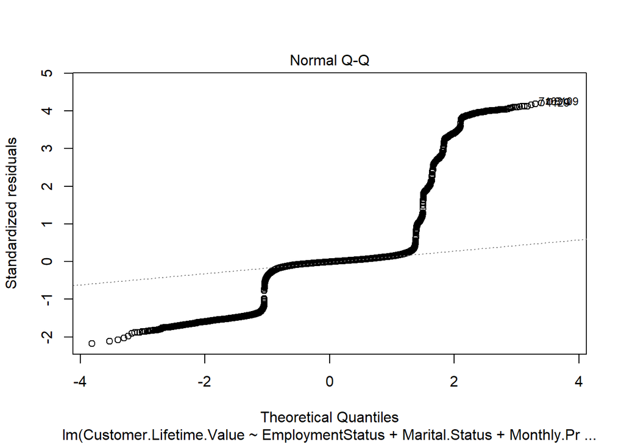

The QQ plot of residuals can be used to visually check the normality assumption. The normal probability plot of residuals should approximately follow a straight line.

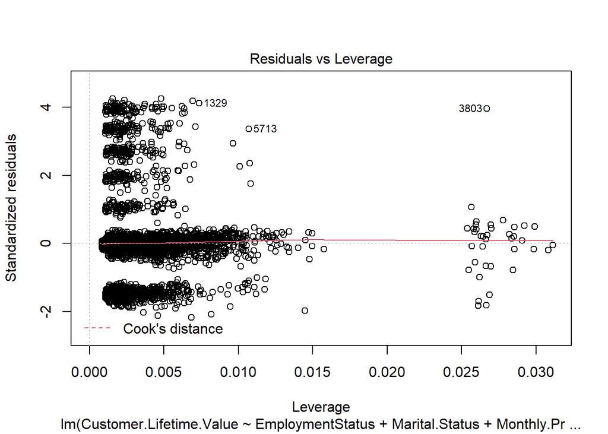

High leverage points:

A data point has high leverage, if it has extreme predictor x values. This can be detected by examining the leverage statistic or the hat-value. A value of this statistic above 2(p + 1)/n indicates an observation with high leverage (P. Bruce and Bruce 2017); where, p is the number of predictors and n is the number of observations.

Influential values An influential value is a value, which inclusion or exclusion can alter the results of the regression analysis. Such a value is associated with a large residual.

The Residuals vs Leverage plot can help us to find influential observations if any. On this plot, outlying values are generally located at the upper right corner or at the lower right corner. Those spots are the places where data points can be influential against a regression line.

When data points have high Cook’s distance scores and are to the upper or lower right of the leverage plot, they have leverage meaning they are influential to the regression results. The regression results will be altered if we exclude those cases.

# Assumpation Testing of Linear Regression Analysis

### 1.Multicollinearity

Checking correlation between independent variables.Variance inflation factor (VIF) is a measure of the amount of multicollinearity in a set of multiple regression variables.vif should be less than 3, here vif all the variables are less than 3 it fails to reject the null hypothesis .There is no multicollinearity

```
##                               GVIF Df GVIF^(1/(2*Df))
## EmploymentStatus          1.277583  4        1.031095
## Marital.Status            1.244559  2        1.056219
## Monthly.Premium.Auto      1.017049  1        1.008488
## Number.of.Open.Complaints 1.036788  5        1.003619
## Number.of.Policies        1.055309  8        1.003370
## Renew.Offer.Type          1.124510  3        1.019750
## Vehicle.Size              1.012179  2        1.003031
```

### 2.Autocorrelation

Null Hypothesis - There is no correlation among residuals.

Alternate hypothesis - Residuals are autocorrelated.

```
##  lag Autocorrelation D-W Statistic p-value
##    1      0.02701474      1.945968   0.024
##  Alternative hypothesis: rho != 0
```

### 3.Heteroscedasticity:

Breuch- Pegon test:It is used to test for heteroskedasticity in a linear regression model. It test whether variance of errors from a regression is dependent on the values of a independent variable.

Null Hypothesis - Heteroskedasticity is present in Residuals.

Alternate hypothesis - Heteroskedasticity is not present in residuals.

```
##
##  studentized Breusch-Pagan test
##
## data:  model7
## BP = 2956.2, df = 25, p-value < 2.2e-16
```

### 4.Normality:

Null Hypothesis - The residuals do not follow a normal distribution.

Alternate hypothesis - The residuals follow a normal distribution.

Anderson Darling test can be used for that

```
##
##  Anderson-Darling normality test
##
## data:  model7$residuals
## A = 869.33, p-value < 2.2e-16
```

P-value ≤ α: The residuals do not follow a normal distribution (Reject H0).P value should be on higher side .But here P is very less. Errors are not normally distributed

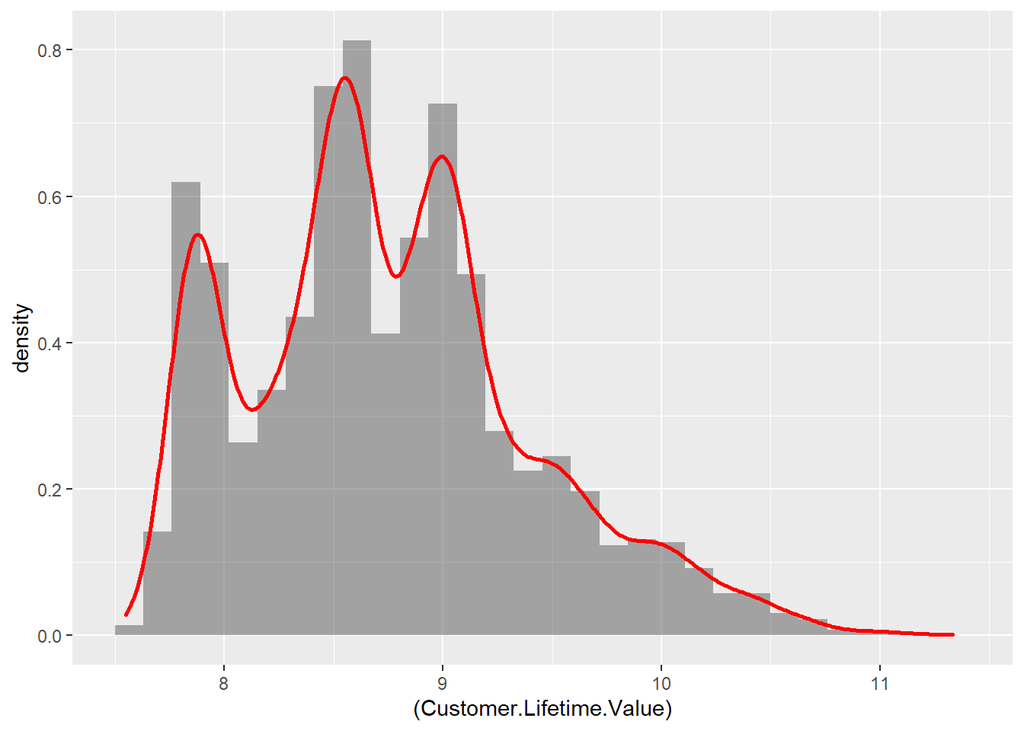

```
## [1] 1844   39
```

```
## [1] 3575   39
```

[output not shown]

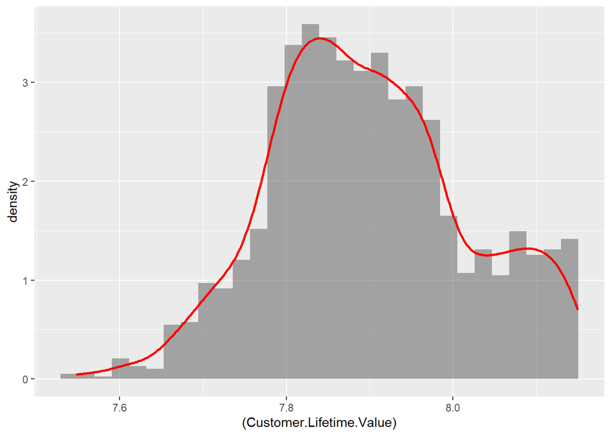

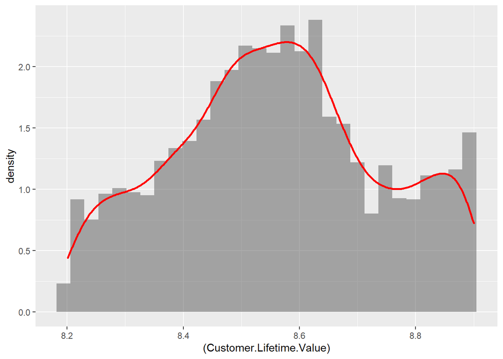

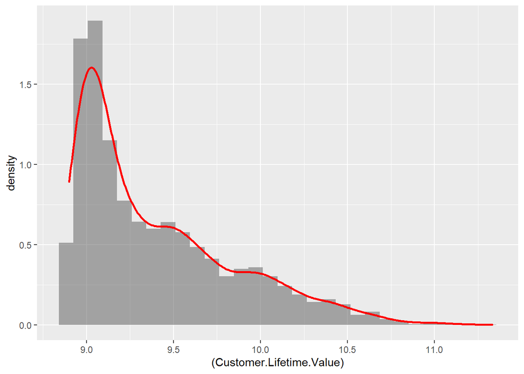

```
## [1] 0.9531083
```

```
## [1] 0.9820321
```

[output not shown]

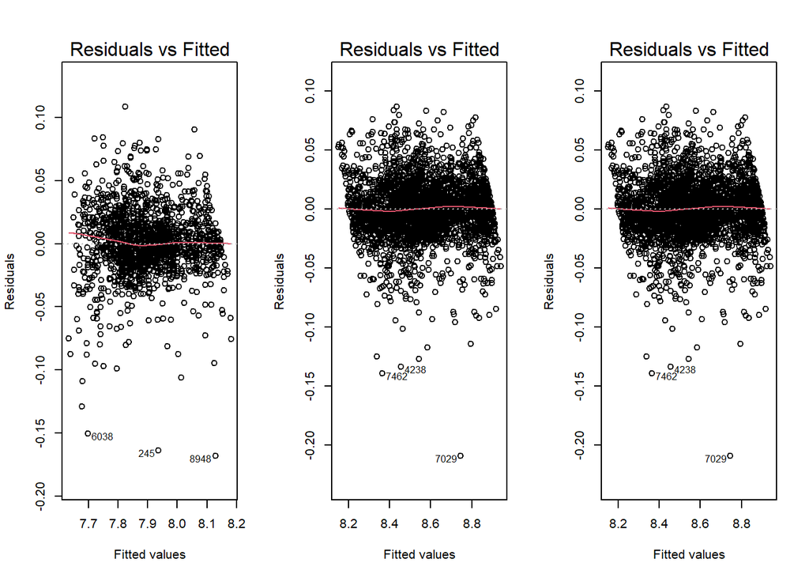

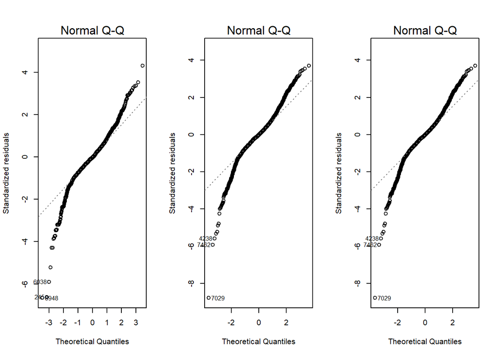

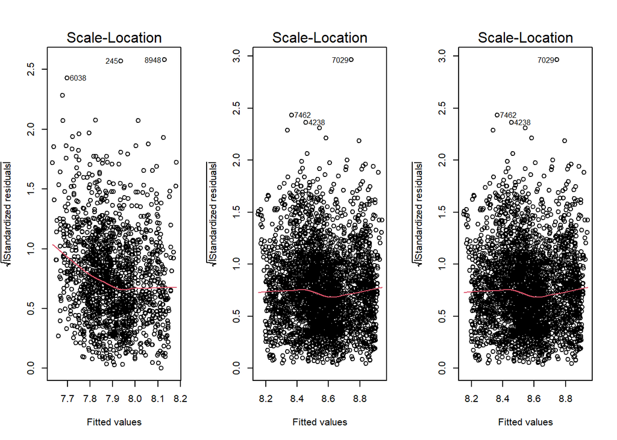

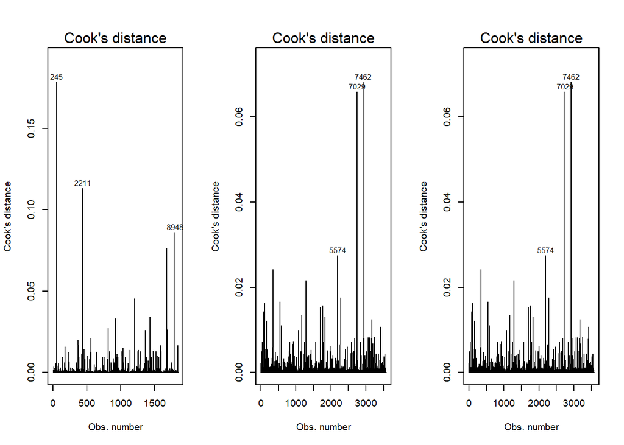

What we done here is that on observing that the distribution of the dependent variable was a combination of three normal distributions we divided the dependent variable into three and made three linear regression models for each and then all three models have very high r square and adjusted r squared. The reason can be that seperating customers into three groups is like based on CLTV is like a short cut to customer segmentation. Although we split the model into three and produced good scores. Choosing the right model for unseen data might introduce error. That’s the drawback of the model. However, more than 73% of those that have premium coverage have CLV more than the median. And more than 60% of basic coverage has a CLV below the median. Also luxury car and luxury suv exclusively only CLV more than the medain. These facts can be used to pick the right model. combining the above three models which have high r squared approximately we will have to use ensemble techniques which is outside the scope of this project.

# Conclusion

This report considered the problem of predicting customer lifetime value (CLV) of cutomers for an automobile insurance firm using linear models. CLV is a measure of the total profit a business can make from the entire lifetime of the relationship with a customer (lifetime being defined as the time period since the start of the relationship till the time the customer moves onto a competitor) Being able to predict/model this is very useful for businesses to help them considerablly reduce the costs of customer aquisition and provide more customer oriented services so as to increase profts. Being able to tell in advance which customer/ group of customers will stay loyal to your business will go a great way in at least maintaining the health of the business. Since CLV is usually calculated using RFM model or the formula, we could have made better models if we had data directly linked to the calculation of CLV such as on the frequency of the claims, customers’ claim amount, the interest rate, frequency of claims, etc.

# Work done

- Amal Joseph (20BDA22): Modelling
- Jerome Francis (20BDA43): Modelling, report writing
- Brinda Dasgupta (20BDA30): EDA, report writing
- Akhil .A. Matthews (20BDA08): EDA, modelling, report writing
- Nancy Prakash Karadi (20BDA03): EDA, report writing
- Tonmoy Dutta (20BDA57): EDA

# References

https://www.thestreet.com/how-to/how-do-insurance-companies-make-money-14971728  
https://www.investopedia.com/ask/answers/052015/what-main-business-model-insurance-companies.asp  
http://www.sthda.com/english/articles/38-regression-model-validation/157-cross-validation-essentials-in-r/  
https://www.sheffield.ac.uk/polopoly_fs/1.714552!/file/stcp-marshall-MannWhitS.pdf  
https://www.quality-control-plan.com/StatGuide/ttest_unpaired_ass_viol.htm  
https://digitalcommons.wayne.edu/cgi/viewcontent.cgi?article=1129&context=jmasm  
https://www.datacamp.com/community/tutorials/customer-life-time-value  
https://www.datacamp.com/community/tutorials/introduction-customer-segmentation-python  
https://medium.com/analytics-vidhya/marketing-analytics-rfm-modeling-855ebec18014